# Practical Machine Learning

Maya Ivanova

July 2nd, 2017

## Background

Using devices such as Jawbone Up, Nike FuelBand, and Fitbit it is now possible to collect a large amount of data about personal activity relatively inexpensively. These type of devices are part of the quantified self-movement - a group of enthusiasts who take measurements about themselves regularly to improve their health, to find patterns in their behavior, or because they are tech geeks. One thing that people regularly do is quantify how much of a particular activity they do, but they rarely quantify how well they do it. In this project, your goal will be to use data from accelerometers on the belt, forearm, arm, and dumbell of 6 participants. They were asked to perform barbell lifts correctly and incorrectly in 5 different ways. More information is available from the website here: http://groupware.les.inf.puc-rio.br/har (see the section on the Weight Lifting Exercise Dataset).

Velloso, E.; Bulling, A.; Gellersen, H.; Ugulino, W.; Fuks, H. “Qualitative Activity Recognition of Weight Lifting Exercises. Proceedings of 4th International Conference in Cooperation with SIGCHI (Augmented Human ’13)”. Stuttgart, Germany: ACM SIGCHI, 2013.

Special thanks to the above mentioned authors for being so generous in allowing their data to be used for this kind of assignment.

## Data loading

```r
rm(list=ls())

library(knitr)
library(caret)
library(rpart)
library(randomForest)
library(tree)
```

```r
#download.file("https://d396qusza40orc.cloudfront.net/predmachlearn/pml-training.csv", destfile = "./pml-training.csv")
#download.file("http://d396qusza40orc.cloudfront.net/predmachlearn/pml-testing.csv", destfile = "./pml-testing.csv")
#setwd("C:/Users/maech/OneDrive/Documents/Courseera/Practical Machine Learning/Week 4/Assignment")
trainingOrig = read.csv("pml-training.csv", na.strings=c("", "NA", "NULL"))
testingOrig = read.csv("pml-testing.csv", na.strings=c("", "NA", "NULL"))
dim(trainingOrig)
```

```
## [1] 19622   160
```

## Data Preparation

```r
# remove columns with NA
training.delna <- trainingOrig[ , colSums(is.na(trainingOrig)) == 0]
#head(training1)
#training3 <- training.decor[ rowSums(is.na(training.decor)) == 0, ]
dim(training.delna)
```

```
## [1] 19622    60
```

```r
# split the data into training and test sets
inTrain <- createDataPartition(training.delna$classe, p=0.7, list=F)
training <- training.delna[inTrain,]
testing <- training.delna[-inTrain,]
dim(training)
```

```
## [1] 13737    60
```

```r
dim(testing)
```

```
## [1] 5885   60
```

```r
# remove identification only variables (columns 1 to 7)
training <- training[, -(1:7)]
testing  <- testing[, -(1:7)]
dim(training)
```

```
## [1] 13737    53
```

## Analysis: Decision Tree Classification

```r
#model fit
set.seed(12345)
tree.training=tree(classe~.,data=training)
summary(tree.training)
```

```
##
## Classification tree:
## tree(formula = classe ~ ., data = training)
## Variables actually used in tree construction:
##  [1] "roll_belt"         "pitch_forearm"     "roll_forearm"
##  [4] "magnet_dumbbell_x" "yaw_belt"          "accel_arm_y"
##  [7] "pitch_belt"        "yaw_dumbbell"      "roll_dumbbell"
## [10] "yaw_arm"           "magnet_dumbbell_y" "magnet_dumbbell_z"
## [13] "accel_forearm_x"
## Number of terminal nodes:  17
## Residual mean deviance:  1.647 = 22600 / 13720
## Misclassification error rate: 0.3246 = 4459 / 13737
```

```r
#Cross-validation
tree.pred=predict(tree.training,testing,type="class")
confMatDecTree <- confusionMatrix(tree.pred, testing$classe)
confMatDecTree
```

```
## Confusion Matrix and Statistics
##
##           Reference
## Prediction    A    B    C    D    E
##          A 1374  174   21   37   31
##          B   21  424   33   15    9
##          C   74  106  767  200  115
##          D  153  236  132  657  237
##          E   52  199   73   55  690
##
## Overall Statistics
##
##                Accuracy : 0.6647
##                  95% CI : (0.6525, 0.6768)
##     No Information Rate : 0.2845
##     P-Value [Acc > NIR] : < 2.2e-16
##
##                   Kappa : 0.5779
##  Mcnemar's Test P-Value : < 2.2e-16
##
## Statistics by Class:
##
##                      Class: A Class: B Class: C Class: D Class: E
## Sensitivity            0.8208  0.37226   0.7476   0.6815   0.6377
## Specificity            0.9375  0.98357   0.8981   0.8460   0.9211
## Pos Pred Value         0.8393  0.84462   0.6078   0.4643   0.6455
## Neg Pred Value         0.9294  0.86717   0.9440   0.9313   0.9186
## Prevalence             0.2845  0.19354   0.1743   0.1638   0.1839
## Detection Rate         0.2335  0.07205   0.1303   0.1116   0.1172
## Detection Prevalence   0.2782  0.08530   0.2144   0.2404   0.1816
## Balanced Accuracy      0.8792  0.67791   0.8228   0.7638   0.7794
```

Overall accuracy is unacceptably low (66%), indicating that decision tree classification is not appropriate to predict this outcome.

## Analysis: Random Forest Classification

```r
rf.training=randomForest(classe~.,data=training,ntree=100, importance=TRUE)
rf.training
```

```
##
## Call:
##  randomForest(formula = classe ~ ., data = training, ntree = 100,      importance = TRUE)
##                Type of random forest: classification
##                      Number of trees: 100
## No. of variables tried at each split: 7
##
##         OOB estimate of  error rate: 0.57%
## Confusion matrix:
##      A    B    C    D    E  class.error
## A 3904    1    0    0    1 0.0005120328
## B   13 2637    8    0    0 0.0079006772
## C    0   14 2375    7    0 0.0087646077
## D    1    0   21 2226    4 0.0115452931
## E    0    1    2    5 2517 0.0031683168
```

Our Random Forest model shows OOB estimate of error rate 0.6% for the training data. Now we will predict it for out-of sample accuracy.

```r
tree.pred=predict(rf.training,testing,type="class")
confMatRF <- confusionMatrix(tree.pred, testing$classe)
confMatRF
```

```
## Confusion Matrix and Statistics
##
##           Reference
## Prediction    A    B    C    D    E
##          A 1671    2    0    0    0
##          B    3 1133    9    0    0
##          C    0    4 1015   10    0
##          D    0    0    2  954    9
##          E    0    0    0    0 1073
##
## Overall Statistics
##
##                Accuracy : 0.9934
##                  95% CI : (0.991, 0.9953)
##     No Information Rate : 0.2845
##     P-Value [Acc > NIR] : < 2.2e-16
##
##                   Kappa : 0.9916
##  Mcnemar's Test P-Value : NA
##
## Statistics by Class:
##
##                      Class: A Class: B Class: C Class: D Class: E
## Sensitivity            0.9982   0.9947   0.9893   0.9896   0.9917
## Specificity            0.9995   0.9975   0.9971   0.9978   1.0000
## Pos Pred Value         0.9988   0.9895   0.9864   0.9886   1.0000
## Neg Pred Value         0.9993   0.9987   0.9977   0.9980   0.9981
## Prevalence             0.2845   0.1935   0.1743   0.1638   0.1839
## Detection Rate         0.2839   0.1925   0.1725   0.1621   0.1823
## Detection Prevalence   0.2843   0.1946   0.1749   0.1640   0.1823
## Balanced Accuracy      0.9989   0.9961   0.9932   0.9937   0.9958
```

Model accuracy is high (99%), indicating that random forests classification is likely to be appropriate to predict this outcome.

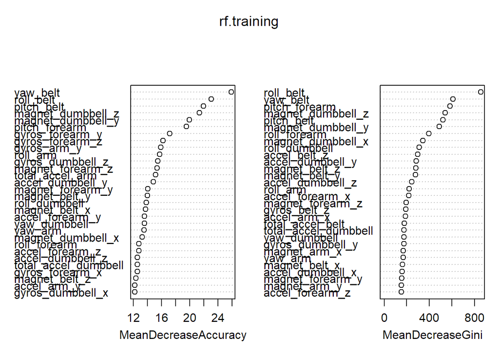

```r
#Which variables are most important in this model?

varImpPlot(rf.training)
```